### Assignment 3

#### Tarin Eccleston

1a,b) Implement the priors for the three parameters in JAGS. Implement the likelihood in JAGS. Hint: JAGS provides the step() function which returns 0 if the argument is negative and 1 otherwise.

Loading coal dataset

```r
library("rjags")
data = data.frame(t=c(1851, 1852, 1853, 1854, 1855, 1856, 1857,
                      1858, 1859, 1860, 1861, 1862, 1863, 1864,
                      1865, 1866, 1867, 1868, 1869, 1870, 1871,
                      1872, 1873, 1874, 1875, 1876, 1877, 1878,
                      1879, 1880, 1881, 1882, 1883, 1884, 1885,
                      1886, 1887, 1888, 1889, 1890, 1891, 1892,
                      1893, 1894, 1895, 1896, 1897, 1898, 1899,
                      1900, 1901, 1902, 1903, 1904, 1905, 1906,
                      1907, 1908, 1909, 1910, 1911, 1912, 1913,
                      1914, 1915, 1916, 1917, 1918, 1919, 1920,
                      1921, 1922, 1923, 1924, 1925, 1926, 1927,
                      1928, 1929, 1930, 1931, 1932, 1933, 1934,
                      1935, 1936, 1937, 1938, 1939, 1940, 1941,
                      1942, 1943, 1944, 1945, 1946, 1947, 1948,
                      1949, 1950, 1951, 1952, 1953, 1954, 1955,
                      1956, 1957, 1958, 1959, 1960, 1961, 1962),
            y=c(4, 5, 4, 1, 0, 4, 3, 4, 0, 6, 3, 3, 4, 0,
                      2, 6, 3, 3, 5, 4, 5, 3, 1, 4, 4, 1, 5, 5,
                      3, 4, 2, 5, 2, 2, 3, 4, 2, 1, 3, 2, 2, 1,
                      1, 1, 1, 3, 0, 0, 1, 0, 1, 1, 0, 0, 3, 1,
                      0, 3, 2, 2, 0, 1, 1, 1, 0, 1, 0, 1, 0, 0,
                      0, 2, 1, 0, 0, 0, 1, 1, 0, 2, 3, 3, 1, 1,
                      2, 1, 1, 1, 1, 2, 4, 2, 0, 0, 0, 1, 4, 0,
                      0, 0, 1, 0, 0, 0, 0, 0, 1, 0, 0, 1, 0, 1))
```

```r
model = "model
{
  # priors
  lambda_1 ~ dunif(0, 10)
  lambda_2 ~ dunif(0, 10)
  t_c ~ dunif(1851, 1962)

  # likelihood
  for(i in 1:length(y))
  {
    y[i] ~ dpois(ifelse(step(t_c - t[i]), lambda_1, lambda_2))
  }

  # prediction node
  t_new <- 1963
  y_new ~ dpois(ifelse(step(t_c - t_new), lambda_1, lambda_2))
}
"
```

Plotting data to know what I’m looking at.

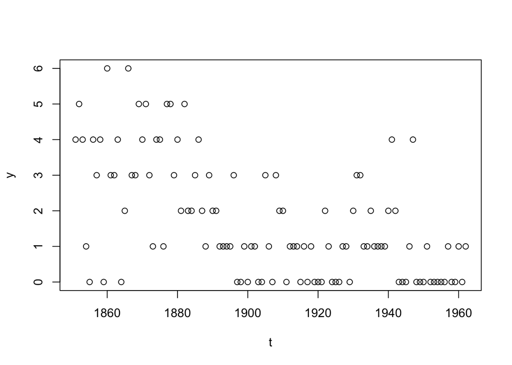

```r
plot(data$t, data$y, xlab = "t", ylab = "y")
```

Running JAGS.

```r
# Variables to monitor
variable_names = c("lambda_1", "lambda_2", "t_c", "y_new")

# How many proper steps?
steps = 100000

# Thinning?
thin = 10

# Create a JAGS model object
jm = jags.model(textConnection(model), data)
# Do some MCMC
results = coda.samples(jm, variable_names, steps, thin=thin)

# Extract chains as data frame
results = as.data.frame(results[[1]])
```

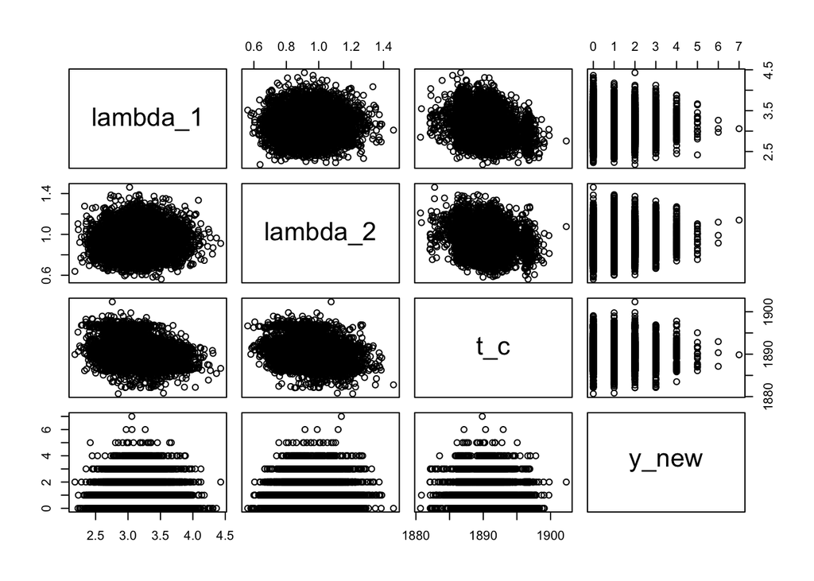

```r
plot(results)
```

Appears uncorrelated, great!

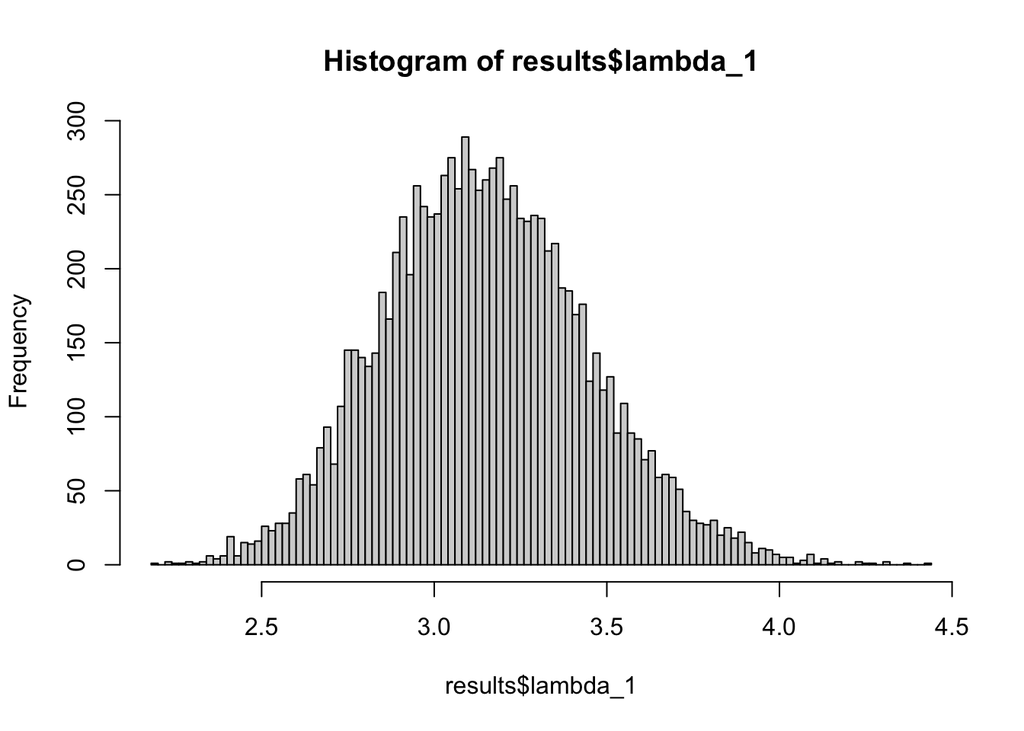

```r
hist(results$lambda_1, breaks = 100)
```

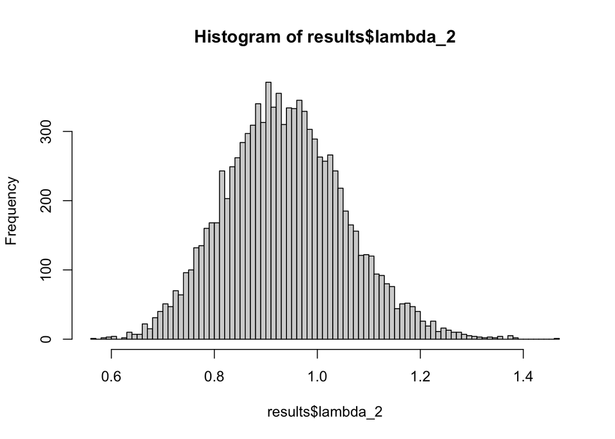

```r
hist(results$lambda_2, breaks = 100)
```

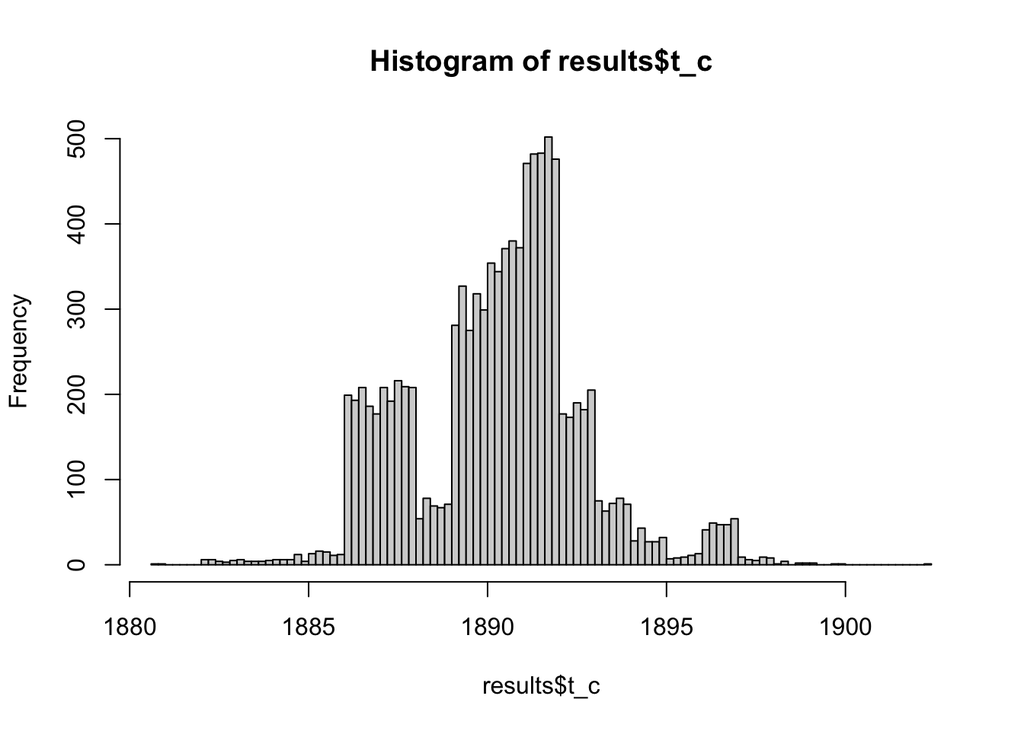

```r
hist(results$t_c, breaks = 100)
```

Multi-modal… that’s the right description right? Appears to be so for t_c due to switching between poisson distribution which uses lambda_1 and lambda_2.

1c) Compute credible intervals for the three parameters.

lambda_1

```r
lambda_1_sorted = sort(results$lambda_1)
l = length(lambda_1_sorted)
c(lambda_1_sorted[0.025*l], lambda_1_sorted[0.975*l])
```

```
## [1] 2.605514 3.765738
```

lambda_2

```r
lambda_2_sorted = sort(results$lambda_2)
l = length(lambda_2_sorted)
c(lambda_2_sorted[0.025*l], lambda_2_sorted[0.975*l])
```

```
## [1] 0.7211328 1.1806636
```

t_c

```r
t_c_sorted = sort(results$t_c)
l = length(t_c_sorted)
c(t_c_sorted[0.025*l], t_c_sorted[0.975*l])
```

```
## [1] 1886.103 1896.188
```

1d) Plot the data with regression curves sampled from the posterior distribution going through it.

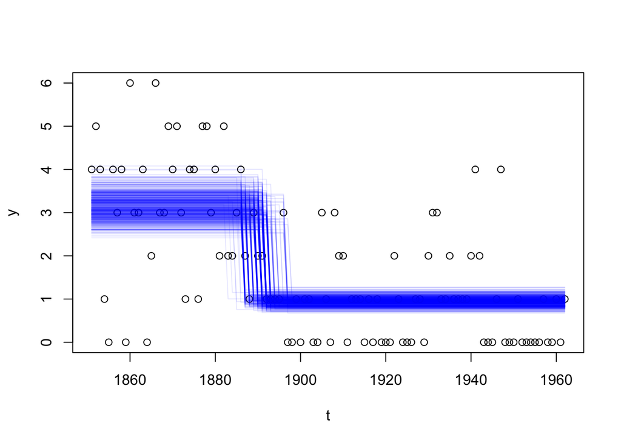

```r
t = seq(min(data$t), max(data$t), by=1)
rows = sample(1:nrow(results), 500)

{
plot(y ~ t, data)

for (row in rows) {
    y <- ifelse(t < results[row, "t_c"],
                results[row, "lambda_1"],
                results[row, "lambda_2"])
    lines(y ~ t, col=rgb(0, 0, 1, 0.1))
}
}
```

Two poisson distributions poisson(lambda_1) and poisson(lambda_2) separated at a distribution of years t_c.

1e) Add a node to the model to predict the number of deaths in 1963, and find the probability that this is three or more.

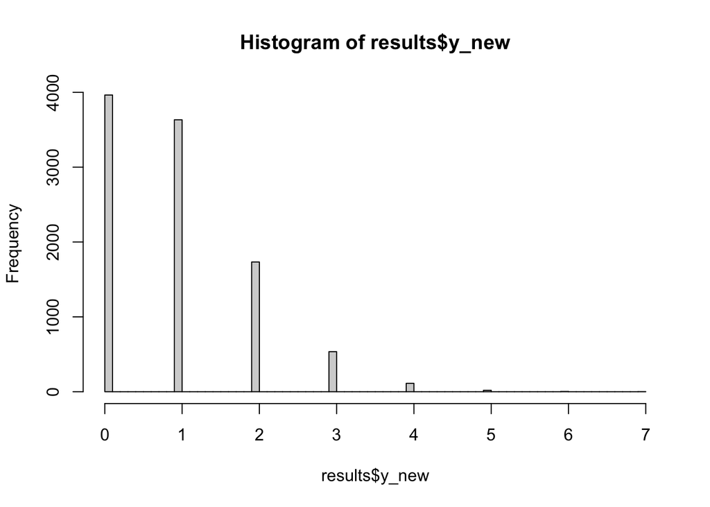

```r
hist(results$y_new, breaks = 100)
```

```r
prob <- sum(results$y_new >= 3) / length(results$y_new)
prob
```

```
## [1] 0.067
```

2a) Draw a PGM for the simple model and a PGM for the hierarchical model. For the latter, I don’t mind whether you explicitly include the deterministic nodes, or merge sigma and log_sigma into one node for presentation purposes.

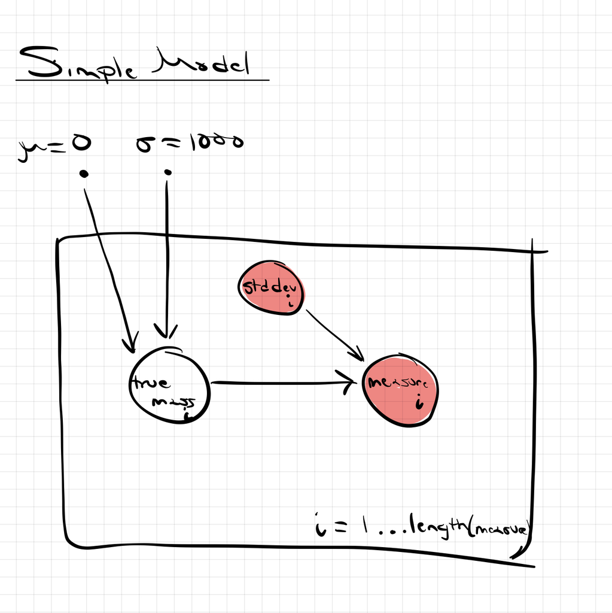

```r
knitr::include_graphics("simple_pgm.png")
```

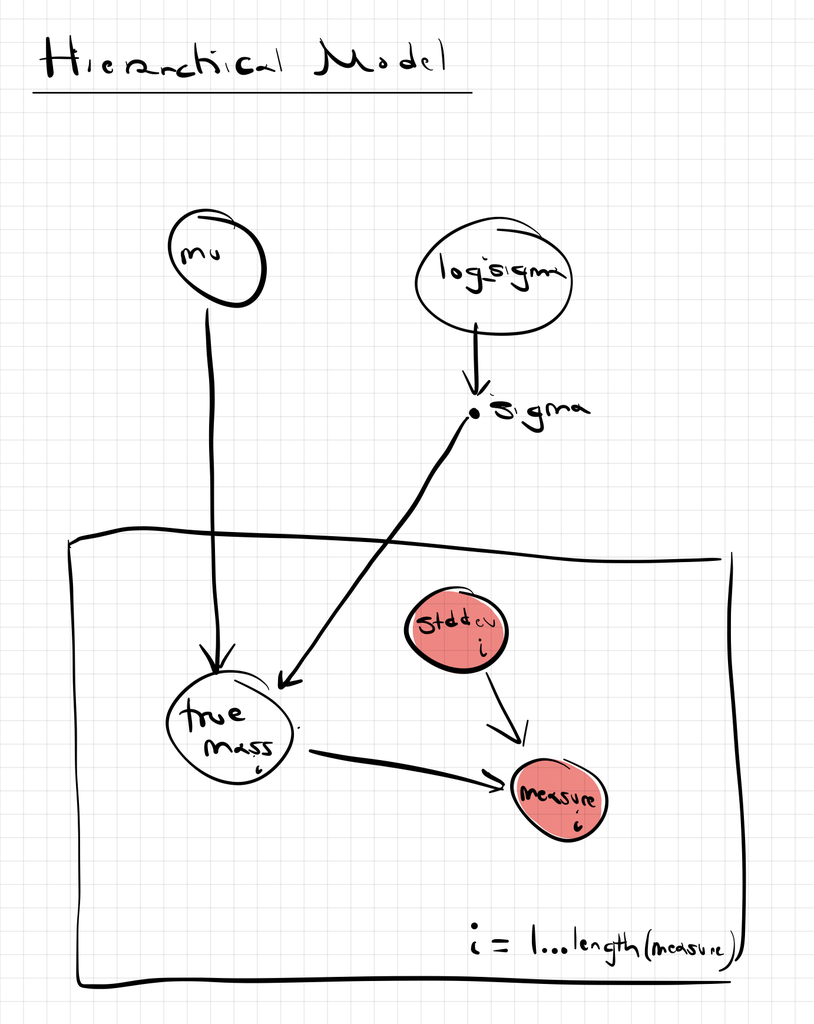

```r
knitr::include_graphics("hier_pgm.png")
```

2b) Run the simple model for a lot of iterations and obtain the posterior distribution for the true log-mass of the first black hole. Summarise it using the posterior mean ± the posterior standard deviation, which for a normal posterior is a 68% central credible interval. The result should be obvious in hindsight.

```r
black_holes_data = read.csv("../data/black_hole_masses.csv")

simple_model = "model {
  # Casual wide prior for each true mass
  for(i in 1:length(measurement))
  {
    true_mass[i] ~ dnorm(0, 1/1000^2)
    measurement[i] ~ dnorm(true_mass[i], 1/stdev[i]^2)
  }
}"
```

Simple Model (Non-Hierarchical)

```r
# Variables to monitor
variable_names_simple = c("true_mass")

# How many proper steps?
steps = 100000

# Thinning?
thin = 10

# Create a JAGS model object
jm_simple = jags.model(textConnection(simple_model), black_holes_data)
# Do some MCMC
results_simple = coda.samples(jm_simple, variable_names_simple, steps, thin=thin)

# Extract chains as data frame
results_simple = as.data.frame(results_simple[[1]])
```

Posterior Distribution of true_mass of first observation

```r
# first method for calculating mean and std
true_mass_1_mean = mean(results_simple$`true_mass[1]`)
true_mass_1_std = sd(results_simple$`true_mass[1]`)

# second method for calculating mean and std
# true_mass_1_sorted = sort(results_simple$`true_mass[1]`)
# l = length(true_mass_1_sorted)
# c(true_mass_1_sorted[0.26*l], true_mass_1_sorted[0.5*l], true_mass_1_sorted[0.84*l])

print(paste("True Mass of First Black Hole - Mean:", true_mass_1_mean,
                ", +- Standard Deviation:", true_mass_1_std))
```

```
## [1] "True Mass of First Black Hole - Mean: 6.47986613699391 , +- Standard Deviation: 0.200147049703883"
```

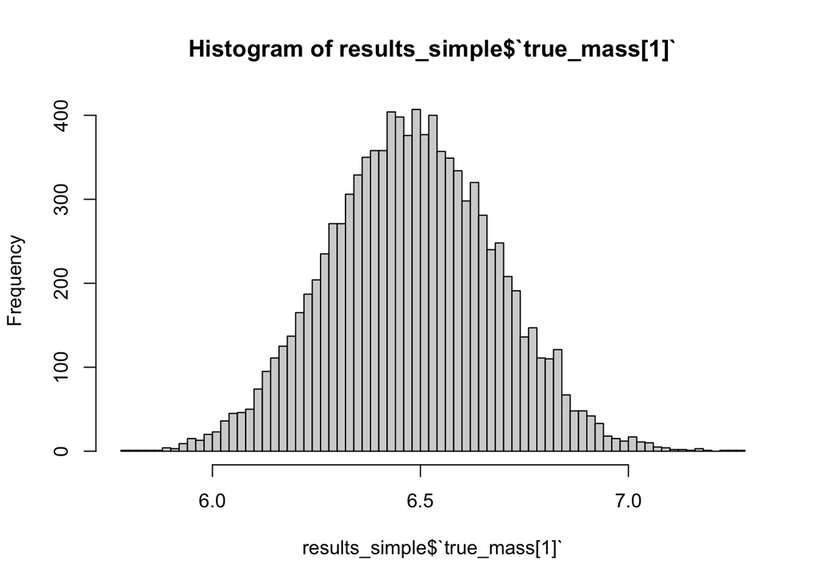

```r
hist_results <- hist(results_simple$`true_mass[1]`, breaks = 100)
```

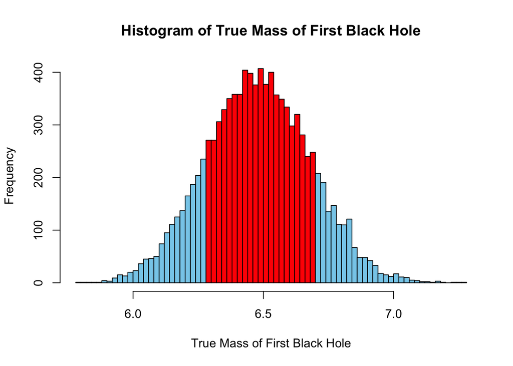

```r
breaks <- hist_results$breaks
colors <- ifelse(breaks >= (true_mass_1_mean - true_mass_1_std) & breaks <= (true_mass_1_mean + true_mass_1_std), "red", "skyblue")

hist(results_simple$`true_mass[1]`, breaks = 100, main = "Histogram of True Mass of First Black Hole",
     xlab = "True Mass of First Black Hole", ylab = "Frequency", col = colors)
```

Appears roughly normally distributed

2c) The hierarchical model’s prior has dependence between σ and the true mass parameters. Modify the model so that it expresses exactly the same prior assumptions, but the the prior has independence between all stochastic nodes. Hint: This is the ‘pre-whitening’ idea that we saw for the starling ANOVA model.

Hierarchical Model with Pre-Whitening

```r
hier_model = "model {
  # Casual wide priors now apply to the hyperparameters
  mu ~ dnorm(0, 1/1000^2)
  log_sigma ~ dnorm(0, 1/10^2)
  sigma <- exp(log_sigma)
  for(i in 1:length(measurement))
  {
    # added pre-whitening
    n[i] ~ dnorm(0, 1)
    true_mass[i] <- mu + sigma*n[i]
    measurement[i] ~ dnorm(true_mass[i], 1/stdev[i]^2)
  }
}"
```

2d) Run either version of the hierarchical model for a lot of iterations and summarise the posterior distributions for mu, sigma, and true mass[1] using any summaries you think are appropriate.

```r
# Variables to monitor
variable_names_hier = c("mu", "sigma", "true_mass")

# How many proper steps?
steps = 1000000

# Thinning?
thin = 100

# Create a JAGS model object
jm_hier = jags.model(textConnection(hier_model), black_holes_data)
# Do some MCMC
results_hier = coda.samples(jm_hier, variable_names_hier, steps, thin=thin)

# Extract chains as data frame
results_hier = as.data.frame(results_hier[[1]])
```

Summary for mu

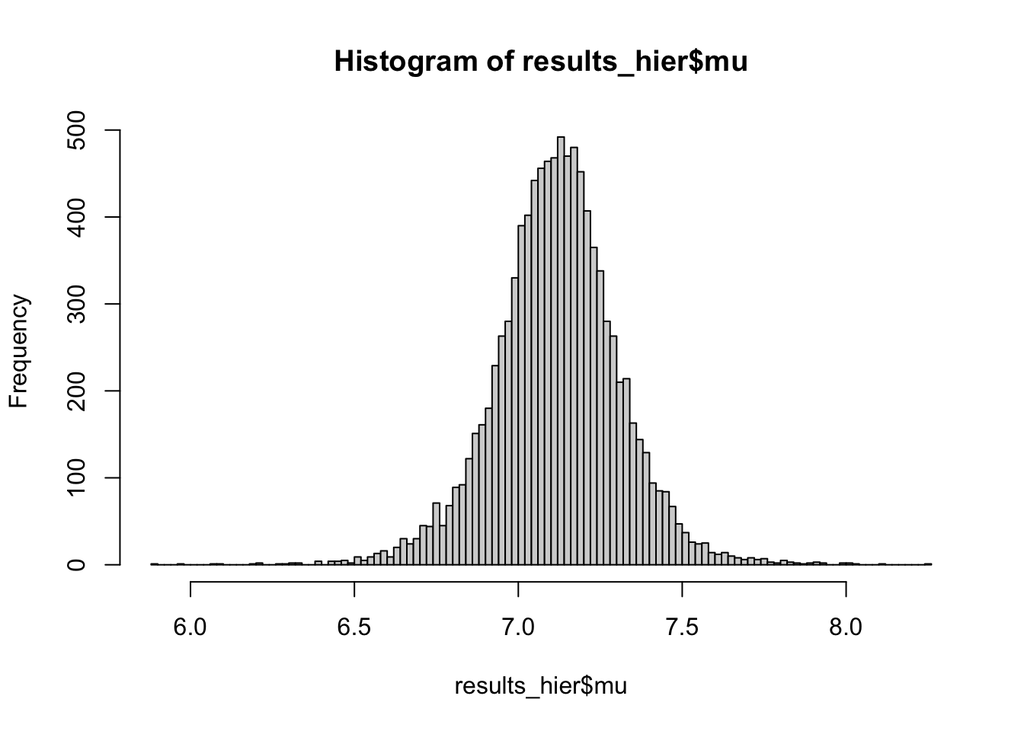

```r
sorted = sort(results_hier$mu)
l = length(sorted)
cred = c(sorted[0.025*l], sorted[0.975*l])

hist_results <- hist(results_hier$mu, breaks = 100)
```

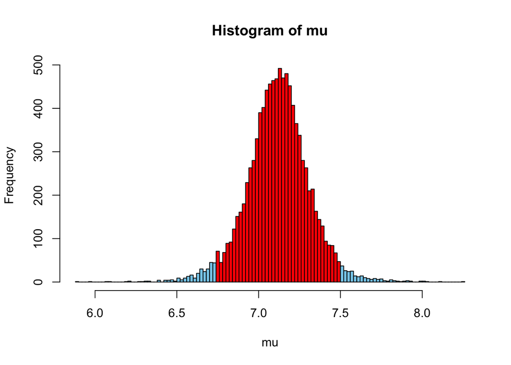

```r
breaks <- hist_results$breaks
colors <- ifelse(breaks >= cred[1] & breaks <= cred[2], "red", "skyblue")

hist(results_hier$mu, breaks = 100, main = "Histogram of mu",
     xlab = "mu", ylab = "Frequency", col = colors)
```

```r
cred
```

```
## [1] 6.725601 7.489207
```

Summary for sigma

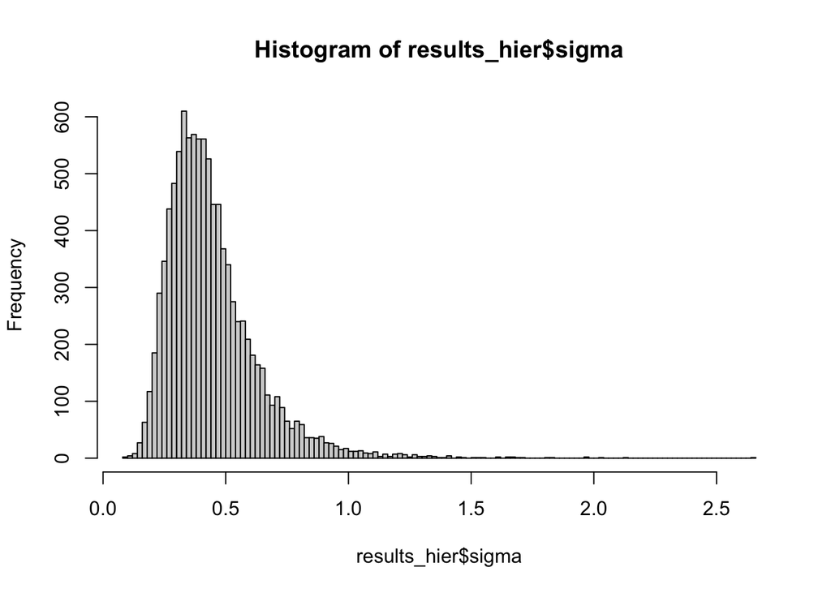

```r
sorted = sort(results_hier$sigma)
l = length(sorted)
cred = c(sorted[0.025*l], sorted[0.975*l])

hist_results <- hist(results_hier$sigma, breaks = 100)
```

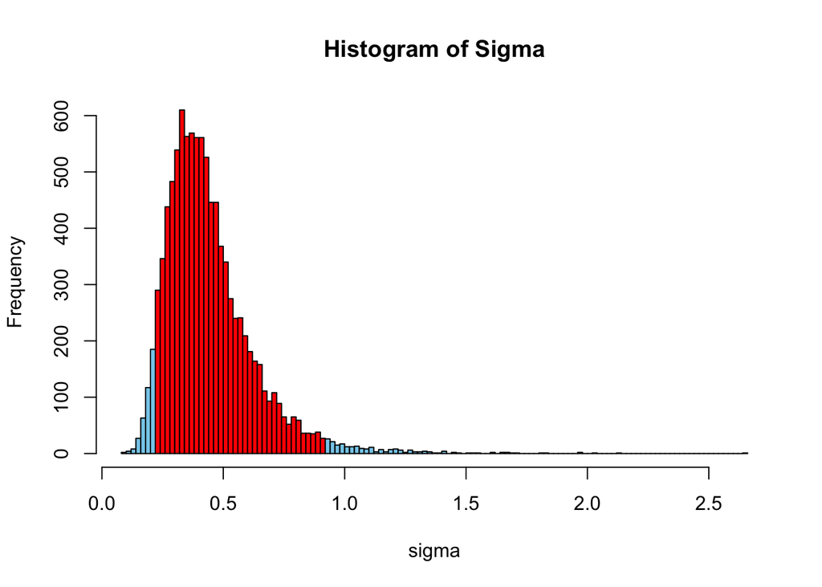

```r
breaks <- hist_results$breaks
colors <- ifelse(breaks >= cred[1] & breaks <= cred[2], "red", "skyblue")

hist(results_hier$sigma, breaks = 100, main = "Histogram of Sigma",
     xlab = "sigma", ylab = "Frequency", col = colors)
```

```r
cred
```

```
## [1] 0.2033123 0.9010955
```

Summary for true_mass[1]

[figure not shown]

```r
sorted = sort(results_hier$`true_mass[1]`)
l = length(sorted)
cred = c(sorted[0.025*l], sorted[0.975*l])

hist_results <- hist(results_simple$`true_mass[1]`, breaks = 100)
```

[figure not shown]

```r
breaks <- hist_results$breaks
colors <- ifelse(breaks >= (true_mass_1_mean - true_mass_1_std) & breaks <= (true_mass_1_mean + true_mass_1_std), "red", "skyblue")

hist(results_simple$`true_mass[1]`, breaks = 100, main = "Histogram of True Mass of First Black Hole",
     xlab = "True Mass of First Black Hole", ylab = "Frequency", col = colors)
```

```r
cred
```

```
## [1] 6.219815 6.994143
```